# Getting started with `gesso`

Natalia Zemlianskaia

2021-03-11

### Purpose of this vignette

This vignette is a tutorial about how to use the `gesso` package

- for the selection of the gene-environment interaction terms in a joint “main-effect-before-interaction” hierarchical manner
- for building a *well-formlated* prediction model containing interaction terms with a specific exposure of interest, where the final prediction model only includes interaction terms for which their respective main effects are also included in the model
- to show how to convert data to sparse/bigmatrix format for more efficient and flexible use of the package

### Overview

The package is developed to fit a regularized regression model that we call **gesso** for the joint selection of gene-environment (GxE) interactions. The model focuses on a single environmental exposure and induces a “main-effect-before-interaction” hierarchical structure. We developed and implemented an efficient fitting algorithm and screening rules that can discard large numbers of irrelevant predictors with high accuracy.

**gesso** model induces hierarchical selection of the (GxE) interaction terms via overlapped group lasso structure. The model has two tuning parameters $\lambda_1$ and $\lambda_2$ allowing flexible, data dependent control over group sparsity and additional interactions sparsity.

Response (outcome) variable can be either quantitative of binary 0/1 variable. For a binary response IRLS procedure is used with custom screening rules we developed.

### Installation

Installation can take a couple of minutes because of the requirement to install dependent packages (`dplyr`, `Rcpp`, `RcppEigen`, `RcppThread`, `BH`, `bigmemory`)

```r
## install.packages("devtools")

library(devtools)
devtools::install_github("NataliaZemlianskaia/gesso")
```

Attaching libraries for the examples below

```r
library(gesso)
library(glmnet)
library(ggplot2)
library(bigmemory)
```

### Data generation

First, we generate the dataset using `data.gen()` function from the package. The function allows us to generate a binary (0/1) matrix of genotypes `G` of a given `sample_size` and `p` number of features, binary vector `E` of environmental measurements, and a response variable `Y` $\sim g(\beta_0 + \beta_E E + \beta_G G + \beta_{G\times E} G\times E)$ - either quantitative or binary depending of the `family` parameter.

We can specify the number of non-zero main effects (`n_g_non_zero`) and interactions (`n_gxe_non_zero`) we want to generate. We also specified a *strong_hierarchical* mode for our dataset, which means that (1) if interaction effect is generated as non-zero, it’s respective genetic main effect is also generated as non-zero $(\beta_{G\times E} \ne 0 \longrightarrow \beta_G \ne 0)$, and (2) effect sizes of the main effects are larger than that of interaction effects $(|\beta_G| \ge |\beta_{G\times E}|)$.

```r
family = "gaussian"
sample_size = 150; p = 400; n_g_non_zero = 10; n_gxe_non_zero = 5

data = data.gen(seed=1, sample_size=sample_size, p=p,
                n_g_non_zero=n_g_non_zero, n_gxe_non_zero=n_gxe_non_zero,
                mode="strong_hierarchical",
                family=family)
```

Let’s look at the dataset we generated `data$G_train`, `data$E_train`, and `data$Y_train`

```r
dim(data$G_train)
```

```
## [1] 150 400
```

```r
head(data$G_train[,1:5])
```

```
##      [,1] [,2] [,3] [,4] [,5]
## [1,]    0    0    0    0    0
## [2,]    0    1    0    1    1
## [3,]    0    0    1    0    0
## [4,]    1    0    0    0    0
## [5,]    0    0    0    0    1
## [6,]    1    0    0    0    0
```

```r
data$E_train[1:10]
```

```
##  [1] 0 0 0 0 0 0 0 0 0 0
```

```r
head(data$Y_train)
```

```
## [1]  5.6849366  0.6601472  8.6602417  2.9610805  8.2804916 -2.3606432
```

We generated model coefficients `data$Beta_G` and `data$Beta_GxE` such that we got `sum(data$Beta_G != 0)` = 10 non-zero main effects and `sum(data$Beta_GxE != 0)` = 5 non-zero interaction effects as we specified.

```r
c(sum(data$Beta_G != 0), sum(data$Beta_GxE != 0))
```

```
## [1] 10  5
```

We also imposed *strong_hierarchical* relationships between main effects and interaction effects

```r
cbind(data$Beta_G[data$Beta_G != 0], data$Beta_GxE[data$Beta_G != 0])
```

```
##       [,1] [,2]
##  [1,]    3 -1.5
##  [2,]   -3 -1.5
##  [3,]    3 -1.5
##  [4,]    3  0.0
##  [5,]    3 -1.5
##  [6,]    3  0.0
##  [7,]    3  0.0
##  [8,]    3  0.0
##  [9,]    3  1.5
## [10,]    3  0.0
```

### Selection example

To tune the model over a 2D grid of hyper-parameters (lambda_1 and lambda_2) we use function `gesso.cv()`, where we specify

- our data `G, E, Y` and `family` parameter for the response variable; matrix `G` should be a numeric matrix, vector `E` should be a numeric vector. Vector `Y` could either be a numeric or binary 0/1 vector
- `tolerance` for the convergence of the fitting algorithm
- `grid_size` to automatically generate grid values for cross-validation
- `nfolds` to specify how many folds we want to use in cross-validation
- `parallel` TRUE to enable parallel cross-validation
- `seed` set random seed to control random folds assignments
- `normalize` TRUE to normalize matrix `G` (such that column-wise sd is eqial to 1)

```r
tolerance = 1e-4
start = Sys.time()
tune_model = gesso.cv(G=data$G_train, E=data$E_train, Y=data$Y_train,
                           family=family, grid_size=20, tolerance=tolerance,
                           parallel=TRUE, nfolds=3,
                           normalize=TRUE,
                           seed=1)
```

```
## [1] "Parallel cv"
## Time difference of 8.51829 secs
## [1] "fit on full data"
## Time difference of 10.88938 secs
```

```r
Sys.time() - start
```

```
## Time difference of 19.42 secs
```

#### Obtain best model with `gesso.coef()` function

To obtain interaction and main effect coefficients corresponding to the model with a particular pair of tuning parameters we use `gesso.coef()` function. We need to specify a model fit object and a pair of lambda = (lambda_1, lambda_2) values organized in a tibble (ex: `lambda = tibble(lambda_1=tune_model$grid[1], lambda_2=tune_model$grid[1])`).

Below we set `fit = tune_model$fit` - model fit on the full dataset and `lambda = tune_model$lambda_min` - the pair of tuning parameters corresponding to the minimum cross-validation error that `gesso.cv()` function returns.

```r
coefficients = gesso.coef(fit=tune_model$fit, lambda=tune_model$lambda_min)
gxe_coefficients = coefficients$beta_gxe
g_coefficients = coefficients$beta_g
```

Check if all non-zero interaction features were recovered by the model

```r
cbind(data$Beta_GxE[data$Beta_GxE != 0], gxe_coefficients[data$Beta_GxE != 0])
```

```
##      [,1]       [,2]
## [1,] -1.5 -1.0459541
## [2,] -1.5 -2.3786590
## [3,] -1.5 -0.7458543
## [4,] -1.5 -1.2026406
## [5,]  1.5  2.1761025
```

Check that the largest estimated interaction effects correspond to the true non-zero coefficients

```r
(data$Beta_GxE[order(abs(gxe_coefficients), decreasing=TRUE)])[1:10]
```

```
##  [1] -1.5  1.5 -1.5 -1.5 -1.5  0.0  0.0  0.0  0.0  0.0
```

Calculate principal selection metrics with `selection.metrics()` funciton available in the package

```r
selection_gesso = selection.metrics(true_b_g=data$Beta_G, true_b_gxe=data$Beta_GxE,
                              estimated_b_g=g_coefficients, estimated_b_gxe=gxe_coefficients)
cbind(selection_gesso)
```

```
##                 selection_gesso
## b_g_non_zero    45
## b_gxe_non_zero  44
## mse_b_g         0.3825209
## mse_b_gxe       0.6469115
## sensitivity_g   1
## specificity_g   0.9102564
## precision_g     0.2222222
## sensitivity_gxe 1
## specificity_gxe 0.9012658
## precision_gxe   0.1136364
## auc_g           0.999999
## auc_gxe         0.999998
```

Compare with the standard Lasso model (we use `glmnet` package)

```r
set.seed(1)
tune_model_glmnet = cv.glmnet(x=cbind(data$E_train, data$G_train, data$G_train * data$E_train),
                              y=data$Y_train,
                              nfolds=3,
                              family=family)

coef_glmnet = coef(tune_model_glmnet, s=tune_model_glmnet$lambda.min)
g_glmnet = coef_glmnet[3: (p + 2)]
gxe_glmnet = coef_glmnet[(p + 3): (2 * p + 2)]

cbind(data$Beta_GxE[data$Beta_GxE != 0], gxe_glmnet[data$Beta_GxE != 0])
```

```
##      [,1]       [,2]
## [1,] -1.5  0.0000000
## [2,] -1.5 -0.0224555
## [3,] -1.5  0.0000000
## [4,] -1.5  0.0000000
## [5,]  1.5  1.2517060
```

```r
(data$Beta_GxE[order(abs(gxe_glmnet), decreasing=TRUE)])[1:10]
```

```
##  [1] 1.5 0.0 0.0 0.0 0.0 0.0 0.0 0.0 0.0 0.0
```

```r
selection_glmnet = selection.metrics(data$Beta_G, data$Beta_GxE, g_glmnet, gxe_glmnet)
cbind(selection_gesso, selection_glmnet)
```

```
##                 selection_gesso selection_glmnet
## b_g_non_zero    45              62
## b_gxe_non_zero  44              26
## mse_b_g         0.3825209       0.2966215
## mse_b_gxe       0.6469115       1.341252
## sensitivity_g   1               1
## specificity_g   0.9102564       0.8666667
## precision_g     0.2222222       0.1612903
## sensitivity_gxe 1               0.4
## specificity_gxe 0.9012658       0.9392405
## precision_gxe   0.1136364       0.07692308
## auc_g           0.999999        0.999999
## auc_gxe         0.999998        0.8405046
```

#### Obtain target model with `gesso.coefnum()` function

To control how parsimonious is our model with respect to the selected non-zero interaction terms we can use `gesso.coefnum()` function. We obtain interaction and main effect coefficients corresponding to the target GxE model, where instead of specifying tuning parameters `lambda`, we set `target_b_gxe_non_zero` parameter which is the number of *at most* (specify `less_than=TRUE` - default value) or *at leats* (specify `less_than=FALSE`) non-zero interactions we want to include in the model, depending on the parameter `less_than`.

The target model is selected based on the averaged cross-validation (cv) results (tune_model$cv_result): for each pair of parameters lambda=(lambda_1, lambda_2) in the grid and for each cv fold we obtain a number of non-zero estimated interaction terms, then average cv results by lambda and choose the tuning parameters corresponding to the minimum average cv loss that have *at most* or *at least* `target_b_gxe_non_zero` non-zero interaction terms. Returned coefficients are obtained by fitting the model on the full dataset with the selected tuning parameters.

Note that the number of estimated non-zero interactions will only approximately reflect the numbers obtained on cv datasets.

```r
coefficients = gesso.coefnum(cv_model=tune_model, target_b_gxe_non_zero=10)
gxe_coefficients = coefficients$beta_gxe
g_coefficients = coefficients$beta_g
```

Calculate principal selection metrics

```r
selection_gesso = selection.metrics(data$Beta_G, data$Beta_GxE, g_coefficients, gxe_coefficients)
cbind(selection_gesso, selection_glmnet)
```

```
##                 selection_gesso selection_glmnet
## b_g_non_zero    38              62
## b_gxe_non_zero  7               26
## mse_b_g         0.3793121       0.2966215
## mse_b_gxe       1.110767        1.341252
## sensitivity_g   1               1
## specificity_g   0.9282051       0.8666667
## precision_g     0.2631579       0.1612903
## sensitivity_gxe 0.6             0.4
## specificity_gxe 0.9898734       0.9392405
## precision_gxe   0.4285714       0.07692308
## auc_g           0.999999        0.999999
## auc_gxe         0.9584791       0.8405046
```

### Prediction example

With `gesso.coef()` we, again, obtain coefficients corresponding to the best model in terms of minimal cross-validated error and use `gesso.predict()` function to apply our estimated model to a new test dataset that can also be generated by the function `data.gen()`.

We calculate test R-squared to assess model performance.

```r
coefficients = gesso.coef(tune_model$fit, tune_model$lambda_min)
beta_0 = coefficients$beta_0; beta_e = coefficients$beta_e
beta_g = coefficients$beta_g; beta_gxe = coefficients$beta_gxe

new_G = data$G_test; new_E = data$E_test
new_Y = gesso.predict(beta_0, beta_e, beta_g, beta_gxe, new_G, new_E)
test_R2_gesso = cor(new_Y, data$Y_test)^2
```

Compare with the standard Lasso (we use `glmnet` package)

```r
new_Y_glmnet = predict(tune_model_glmnet, newx=cbind(new_E, new_G, new_G * new_E),
                       s=tune_model_glmnet$lambda.min)
test_R2_glmnet = cor(new_Y_glmnet[,1], data$Y_test)^2
cbind(test_R2_gesso, test_R2_glmnet)
```

```
##      test_R2_gesso test_R2_glmnet
## [1,]     0.9736186      0.9437631
```

### Sparse matrix option example

We generate a large highly sparse genotype matrix `G` by setting genotype prevalence parameter `pG` to 0.03 and measure how long does it take to fit the model.

```r
sample_size = 600; p = 30000
pG = 0.03
data = data.gen(seed=1, sample_size=sample_size, p=p,
                n_g_non_zero=n_g_non_zero, n_gxe_non_zero=n_gxe_non_zero,
                mode = "strong_hierarchical",
                pG=pG,
                family=family)
sum(data$G_train != 0) / (sample_size * p)
```

```
## [1] 0.03003111
```

```r
start = Sys.time()
fit = gesso.fit(G=data$G_train, E=data$E_train, Y=data$Y_train,
                     tolerance=tolerance,
                     normalize=TRUE)
time_non_sparse = Sys.time() - start; time_non_sparse
```

```
## Time difference of 1.431981 mins
```

We then convert our generated matrix to sparse format and measure fitting time again.

```r
G_train_sparse = as(data$G_train, "dgCMatrix")

start = Sys.time()
fit = gesso.fit(G=G_train_sparse, E=data$E_train, Y=data$Y_train,
                     tolerance=tolerance,
                     normalize=TRUE)
time_sparse = Sys.time() - start; time_sparse
```

```
## Time difference of 37.82913 secs
```

We see that sparse option enables more efficient fitting, however, the speed-up works only for substantially sparse matrices.

```r
(as.numeric(time_non_sparse) * 60) / as.numeric(time_sparse)
```

```
## [1] 2.271236
```

### Bigmatrix (`bigmemory` package) option example

Here we show how to convert data into `bigmatrix` format. This format should be used for a very large datasets that barely fit in RAM.

For out of RAM objects function `attach.big.matrix("g_train.desc")` should be used given that the files already exist in a correct format (`g_train.desc`, `g_train.bin`).

```r
grid = compute.grid(data$G_train, data$E_train, data$Y_train,
                    normalize=TRUE, grid_size=grid_size, grid_min_ratio=1e-4)

G_train = as.big.matrix(data$G_train,
                        backingfile="g_train.bin",
                        descriptorfile="g_train.desc")
## is.filebacked(G_train) should return TRUE

fit_bm = gesso.fit(G_train, data$E_train, data$Y_train,
                     tolerance=tolerance, grid=grid, family=family)

tune_model_bm = gesso.cv(G_train, data$E_train, data$Y_train,
                              family=family, grid=grid, tolerance=tolerance,
                              parallel=TRUE, nfolds=3,
                              normalize=TRUE, seed=1)
```

### Working sets

We use the same large dataset that we generated for the sparse matrices example to demonstrate how our screening rules work

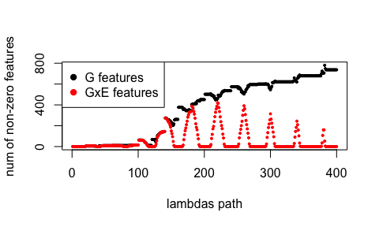

```r
plot(fit$beta_g_nonzero, pch=19, cex=0.4,
     ylab="num of non-zero features", xlab="lambdas path")
points(fit$beta_gxe_nonzero, pch=19, cex=0.4, col="red")
legend("topleft", legend=c("G features", "GxE features"), col=c("black", "red"), pch=19)
```

```r
sum(fit$working_set_size > 3000)/ length(fit$working_set_size)
```

```
## [1] 0.1625
```

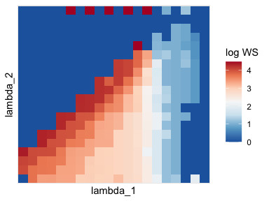

```r
df = data.frame(lambda_1_factor = factor(fit$lambda_1),
                lambda_2_factor = factor(fit$lambda_2),
                ws = fit$working_set_size)

log_0 = function(x){
  return(ifelse(x == 0, 0, log10(x)))
}

ggplot(df, aes(lambda_1_factor, lambda_2_factor, fill=log_0(ws))) +
  scale_fill_distiller(palette = "RdBu") +
  scale_x_discrete("lambda_1", breaks=c(1)) +
  scale_y_discrete("lambda_2", breaks=c(1)) +
  labs(fill='log WS') +
  geom_tile()
```